# Homework 8

Glenn Clapp

2018-11-01

This function will be used to analyze regression models throughout this homework.

```r
> residual.analysis <- function(model) {
+   print( xyplot(rstandard(model)~predict(model)) )
+   print( qqmath(resid(model),
+                 panel=function(...){
+                   panel.qqmath(...)
+                   panel.qqmathline(resid(model))
+                 })
+   )
+ }
```

9.3.4 (2pts)

Reiss et al. compared point-of-care and standard hospital laboratory assays for monitoring patients receiving a single anticoagulant or a regimen consisting of a combination of anticoagulants. It is quite common when comparing two measuring techniques, to use regression analysis in which one variable is used to predict another. In the present study, the researchers obtained measures of international normalized ratio (INR) by assay of capillary and venous blood samples collected from 90 subjects taking warfarin. INR, used especially when patients are receiving warfarin, measures the clotting ability of the blood. Point-of-care testing for INR was conducted with the CoaguChek assay product. Hospital testing was done with standard hospital laboratory assays. The authors used the hospital assay INR level to predict the CoaguChek INR level. The meaurements are given in the following table.

```r
> Blood = read_csv("EXR_C09_S03_04.csv")
```

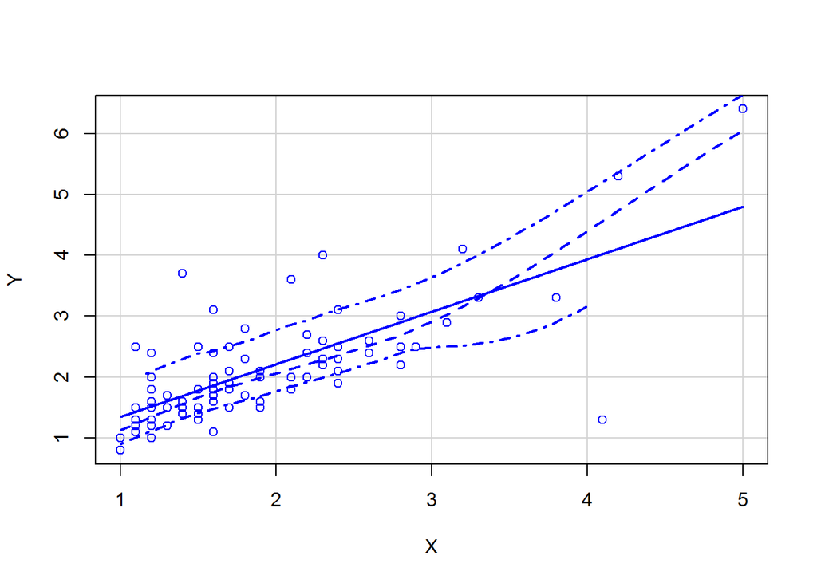

```r
> scatterplot(Y~X, data=Blood, boxplots=F )
```

```r
> Regression.Model <- lm(Y~X, data=Blood)
> summary(Regression.Model)
```

```
Call:
lm(formula = Y ~ X, data = Blood)

Residuals:
    Min      1Q  Median      3Q     Max
-2.7248 -0.3357 -0.1341  0.1306  2.0040

Coefficients:
            Estimate Std. Error t value Pr(>|t|)
(Intercept)  0.48848    0.18167   2.689  0.00858 **
X            0.86251    0.08972   9.613 2.24e-15 ***
---
Signif. codes:  0 '***' 0.001 '**' 0.01 '*' 0.05 '.' 0.1 ' ' 1

Residual standard error: 0.64 on 88 degrees of freedom
Multiple R-squared:  0.5122,    Adjusted R-squared:  0.5067
F-statistic: 92.41 on 1 and 88 DF,  p-value: 2.244e-15
```

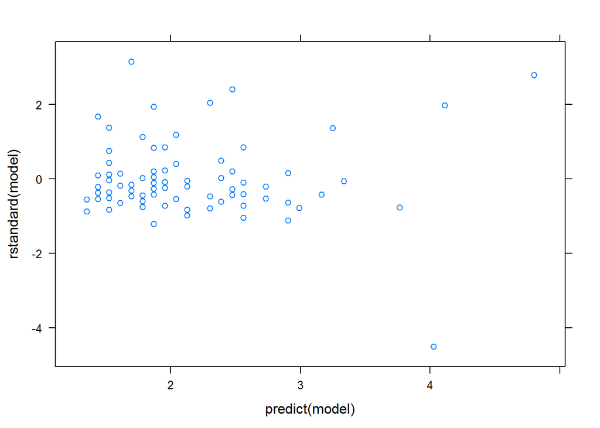

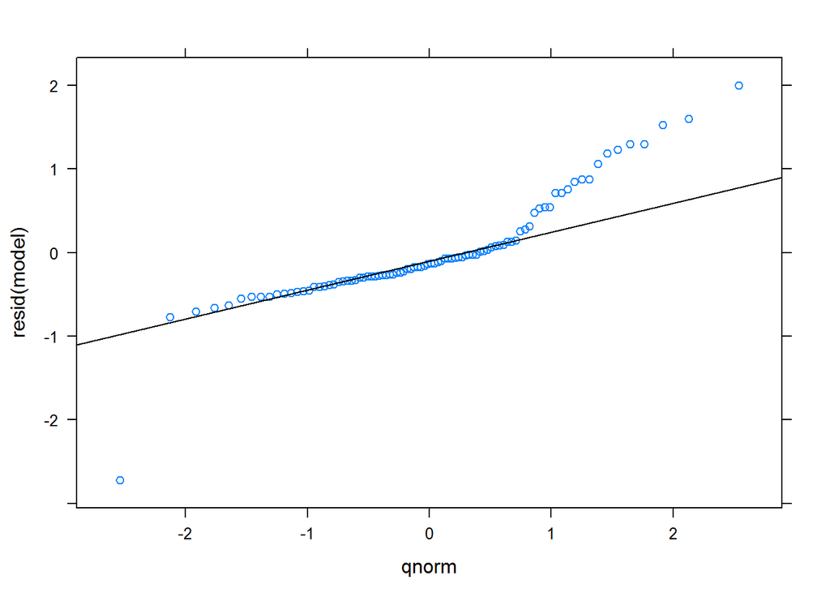

```r
> residual.analysis(Regression.Model)
```

```r
> coef(Regression.Model)
```

```
(Intercept)           X
  0.4884797   0.8625108
```

```r
> confint(Regression.Model) #These are confidence intervals on the coeefficients of the model
```

```
                2.5 %    97.5 %
(Intercept) 0.1274485 0.8495109
X           0.6842054 1.0408162
```

9.4.2 (6pts)

9.5.2(2pts) A. for the value of x indicated, A. contruct the 95 percent confidence interval for $\mu_y|x$ and B. construct the 95 percent prediction interval for Y.

Refer to Exercise 9.3.4 and let X = 1.6

```r
> newdata = data.frame(X=1.6)
> # This creates a point at which we're interested in the intervals. Note that a
> # list of points could be defined with newdata = data.frame(X=c(1,2,3))
> predict(Regression.Model,newdata,interval = 'confidence')
```

```
       fit      lwr      upr
1 1.868497 1.725432 2.011562
```

```r
> predict(Regression.Model,newdata,interval='predict')
```

```
       fit       lwr      upr
1 1.868497 0.5885697 3.148424
```

Chapter 9 review questions: 16 (5pts): A study by Scrogin et al. was designed to assess the effects of concurrent manipulations of dietary NaCl and calcium on blood pressure as well as blood pressure and catecholamine responses to stress. Subjects were salt-sensitive, spontaneously hypertensive male rats. Among the analyses performed by the investigators was a correlation between baseline blood pressure and plasma epinephrine concentration (E). The following data on these two variables were collected. Let $\alpha$ = 0.01.

```r
> REV16 = read_csv("REV_C09_16.csv")
```

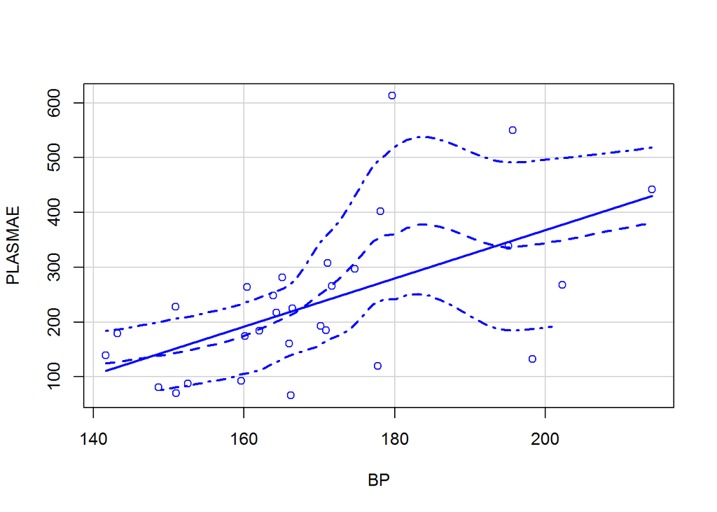

```r
> scatterplot(PLASMAE~BP, data=REV16, boxplots=F )
```

```r
> Regression.Model.REV16 <- lm(PLASMAE~BP, data=REV16)
> summary(Regression.Model.REV16)
```

```
Call:
lm(formula = PLASMAE ~ BP, data = REV16)

Residuals:
    Min      1Q  Median      3Q     Max
-228.26  -61.31    4.56   60.60  334.18

Coefficients:
            Estimate Std. Error t value Pr(>|t|)
(Intercept) -510.156    203.888  -2.502  0.01870 *
BP             4.389      1.195   3.673  0.00104 **
---
Signif. codes:  0 '***' 0.001 '**' 0.01 '*' 0.05 '.' 0.1 ' ' 1

Residual standard error: 112.4 on 27 degrees of freedom
Multiple R-squared:  0.3332,    Adjusted R-squared:  0.3085
F-statistic: 13.49 on 1 and 27 DF,  p-value: 0.001044
```

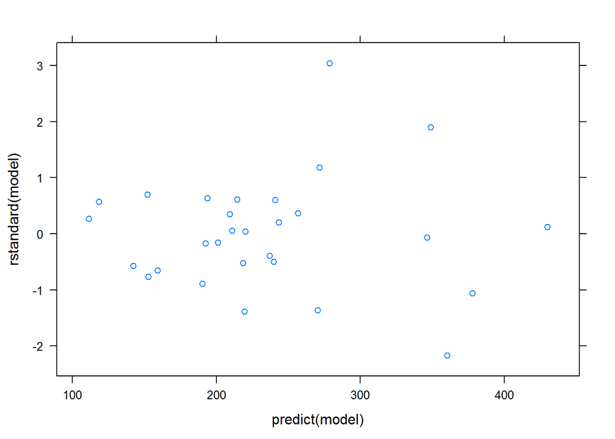

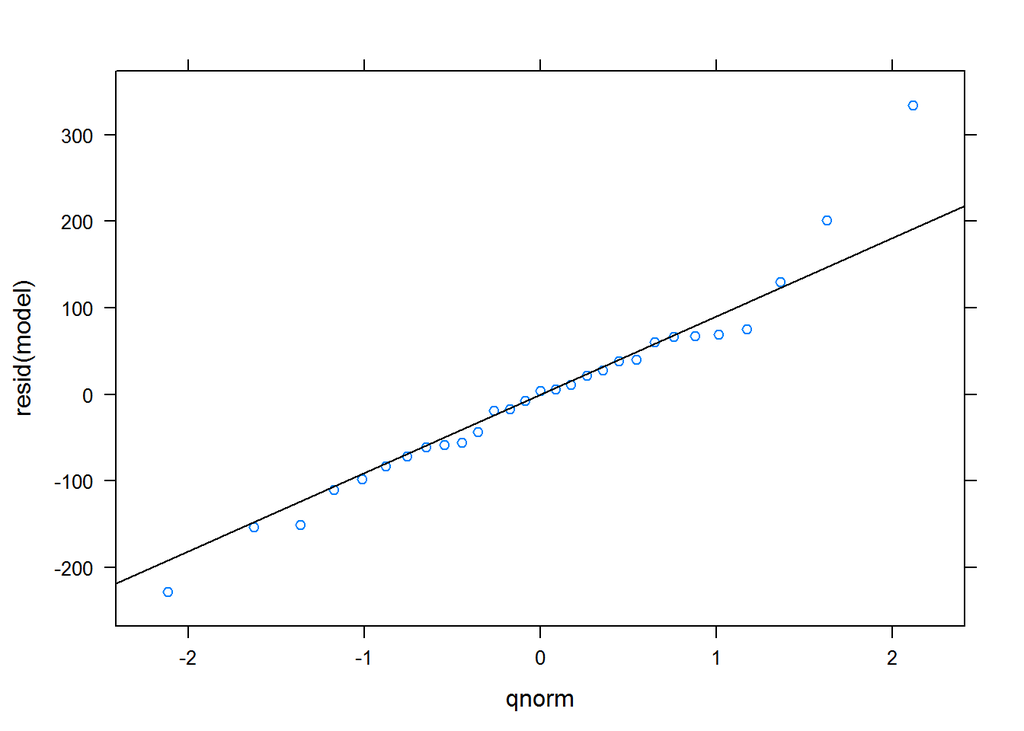

```r
> residual.analysis(Regression.Model.REV16)
```

```r
> coef(Regression.Model.REV16)
```

```
(Intercept)          BP
-510.155626    4.389384
```

```r
> confint(Regression.Model.REV16,level = 0.99) #These are confidence intervals on the coeefficients of the model
```

```
                  0.5 %    99.5 %
(Intercept) -1075.06598 54.754725
BP              1.07824  7.700528
```

There is enough evidence to conclude that there is a positive relationship between blood pressure and plasma. The confidence interval (alpha=0.01) is entirely above zero.

18 (5pts): Run both parametric and non-parametric correlations and comment on the differences seen. Maria Mathias conducted a study of hyperactive children. She measured the children’s attitude, hyperactivity, and social behavior before and after treatment. The following table shows the 31 subjects the age and improvement scores from pre-treatment to post-treatment for attitude (ATT), social behavior (SOC), and hyperactivity (HYP). A negative score for HYP indicates an improvemnent in hyperactivity; a positive score in ATT or SOC indicates improvement. Perform an analysis to determine if there is evidence to indicate that age (years) is correlated with any of the three outcome variables. Let $\alpha$ = 0.05 for all tests.

```r
> CHILD = read_csv("REV_C09_18.csv")
```

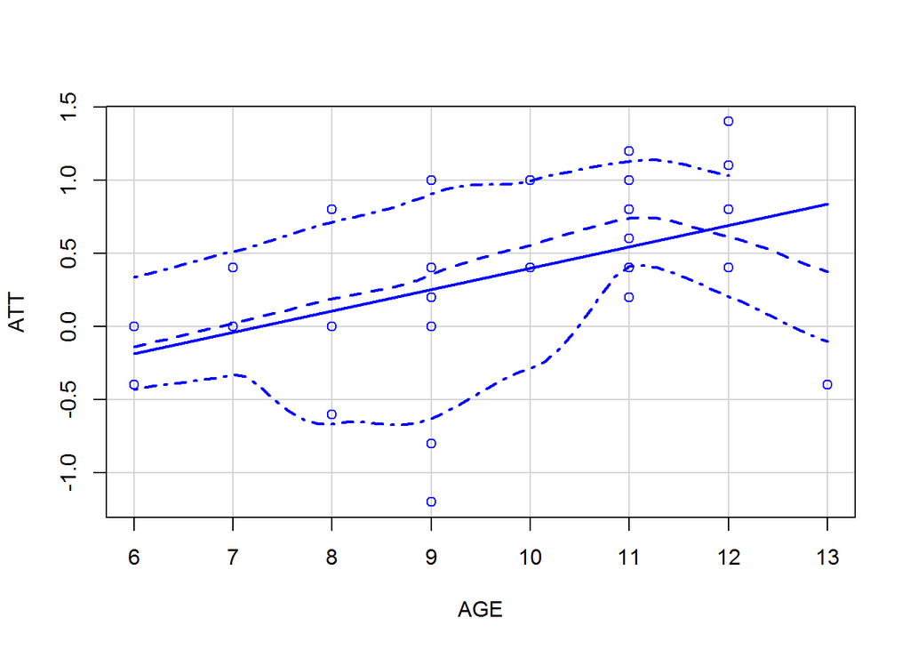

```r
> scatterplot(ATT~AGE, data=CHILD, boxplots=F )
```

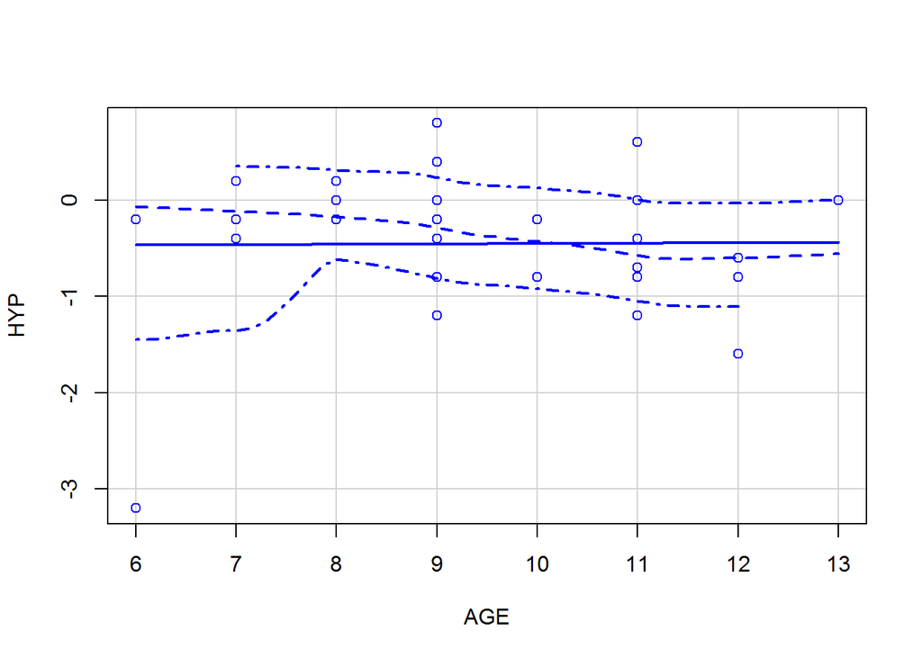

```r
> scatterplot(HYP~AGE, data=CHILD, boxplots=F )
```

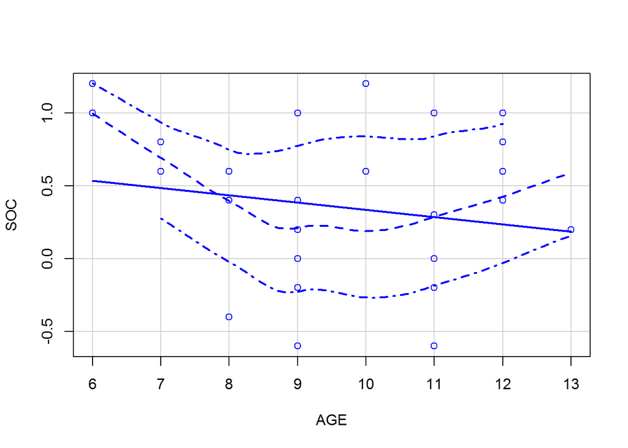

```r
> scatterplot(SOC~AGE, data=CHILD, boxplots=F )
```

```r
> Regression.Model.ATT <- lm(ATT~AGE, data=CHILD)
> Regression.Model.HYP <- lm(ATT~HYP, data=CHILD)
> Regression.Model.SOC <- lm(ATT~SOC, data=CHILD)
>
> summary(Regression.Model.ATT)
```

```
Call:
lm(formula = ATT ~ AGE, data = CHILD)

Residuals:
     Min       1Q   Median       3Q      Max
-1.45208 -0.23275  0.05549  0.44792  0.74792

Coefficients:
            Estimate Std. Error t value Pr(>|t|)
(Intercept) -1.06386    0.60674  -1.753   0.0901 .
AGE          0.14621    0.06239   2.344   0.0262 *
---
Signif. codes:  0 '***' 0.001 '**' 0.01 '*' 0.05 '.' 0.1 ' ' 1

Residual standard error: 0.6413 on 29 degrees of freedom
Multiple R-squared:  0.1592,    Adjusted R-squared:  0.1302
F-statistic: 5.493 on 1 and 29 DF,  p-value: 0.02616
```

```r
> summary(Regression.Model.HYP)
```

```
Call:
lm(formula = ATT ~ HYP, data = CHILD)

Residuals:
     Min       1Q   Median       3Q      Max
-1.57024 -0.31971  0.08029  0.57524  1.00954

Coefficients:
            Estimate Std. Error t value Pr(>|t|)
(Intercept)  0.30960    0.14754   2.098   0.0447 *
HYP         -0.05054    0.17322  -0.292   0.7725
---
Signif. codes:  0 '***' 0.001 '**' 0.01 '*' 0.05 '.' 0.1 ' ' 1

Residual standard error: 0.6984 on 29 degrees of freedom
Multiple R-squared:  0.002927,  Adjusted R-squared:  -0.03146
F-statistic: 0.08512 on 1 and 29 DF,  p-value: 0.7725
```

```r
> summary(Regression.Model.SOC)
```

```
Call:
lm(formula = ATT ~ SOC, data = CHILD)

Residuals:
     Min       1Q   Median       3Q      Max
-1.42682 -0.49184  0.05539  0.52901  0.99650

Coefficients:
            Estimate Std. Error t value Pr(>|t|)
(Intercept)   0.2268     0.1509   1.503    0.144
SOC           0.2945     0.2458   1.198    0.241

Residual standard error: 0.6828 on 29 degrees of freedom
Multiple R-squared:  0.04715,   Adjusted R-squared:  0.0143
F-statistic: 1.435 on 1 and 29 DF,  p-value: 0.2406
```

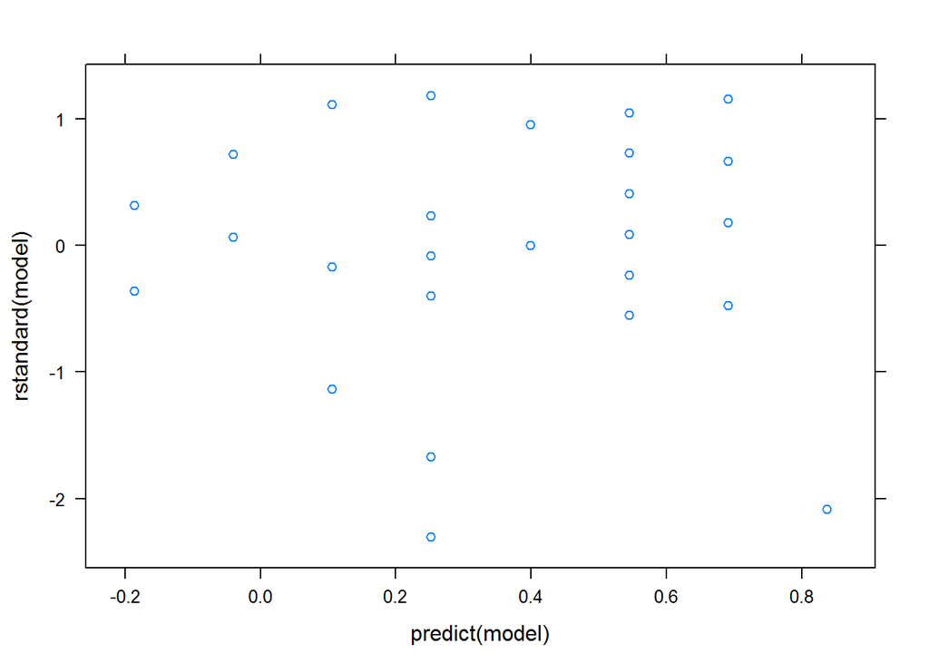

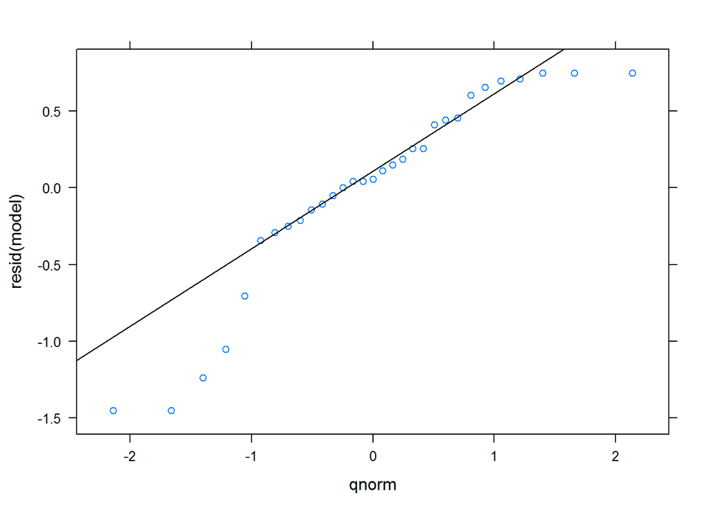

```r
> residual.analysis(Regression.Model.ATT)
```

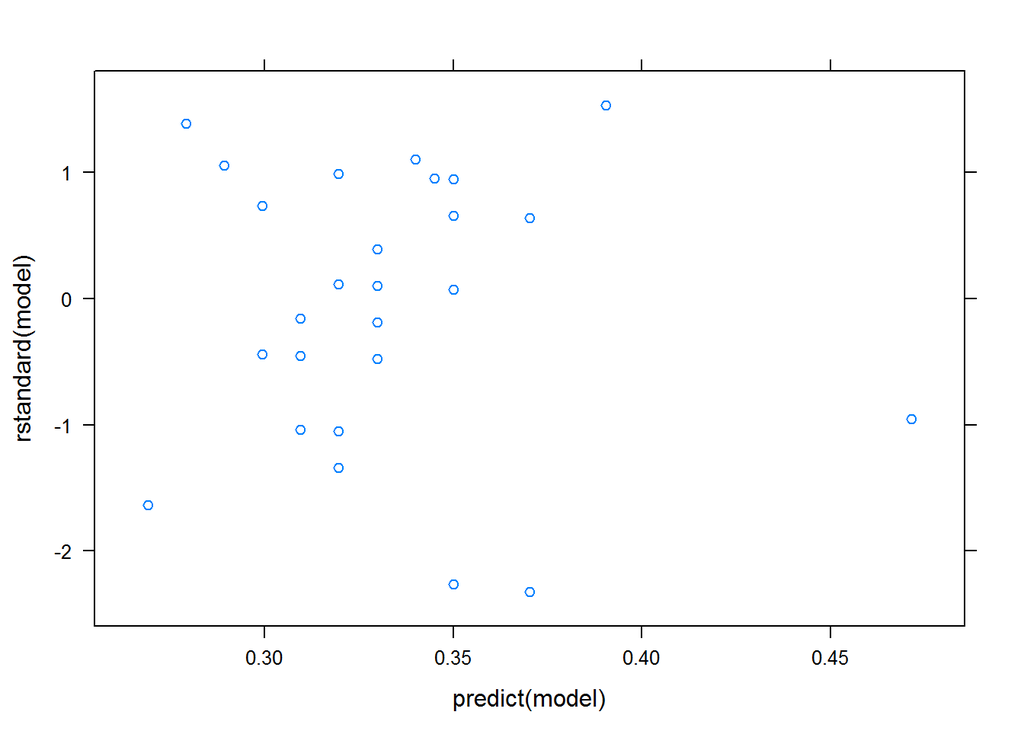

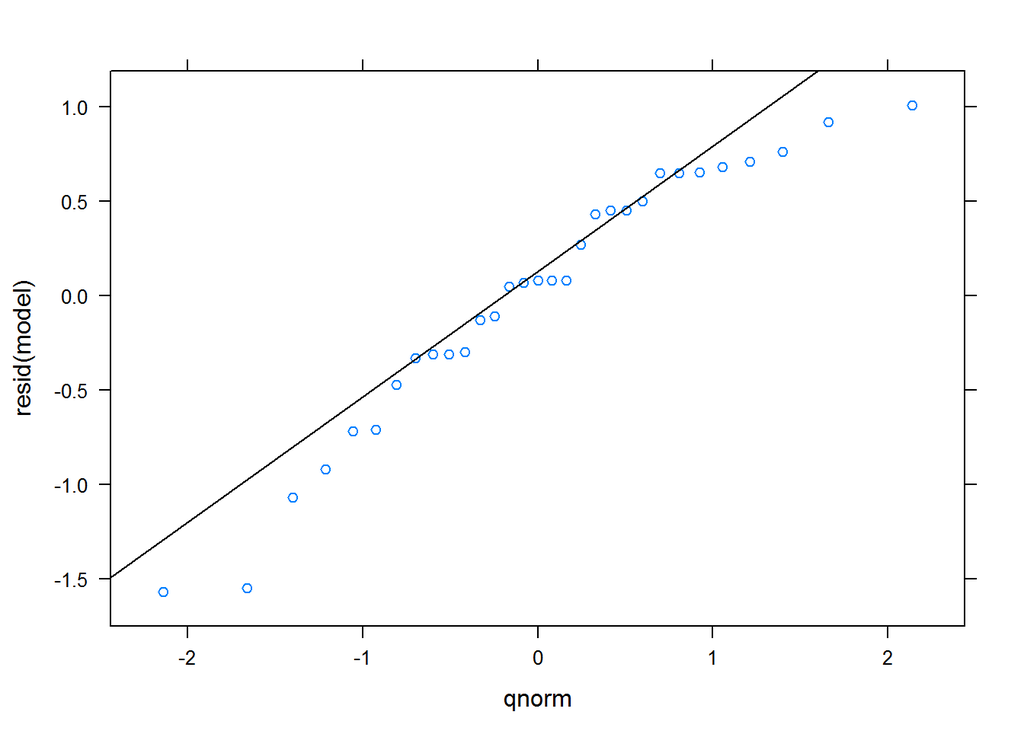

```r
> residual.analysis(Regression.Model.HYP)
```

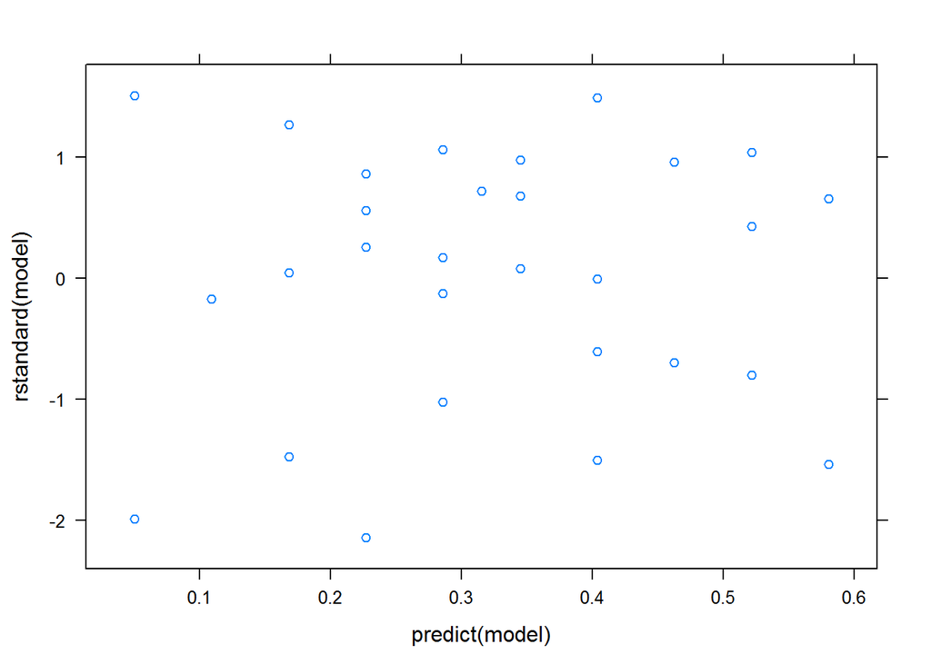

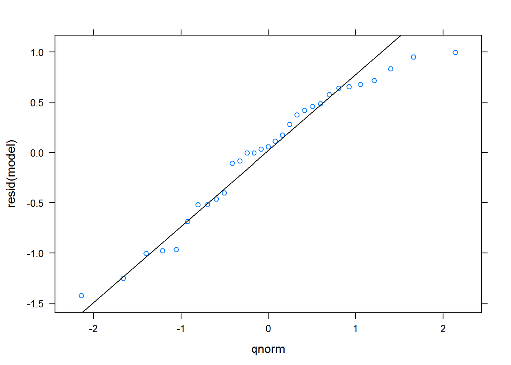

```r
> residual.analysis(Regression.Model.SOC)
```

```r
> coef(Regression.Model.ATT)
```

```
(Intercept)         AGE
 -1.0638584   0.1462149
```

```r
> coef(Regression.Model.HYP)
```

```
(Intercept)         HYP
 0.30959760 -0.05053772
```

```r
> coef(Regression.Model.SOC)
```

```
(Intercept)         SOC
  0.2268208   0.2944644
```

```r
> confint(Regression.Model.ATT,level = 0.95) #These are confidence intervals on the coeefficients of the model
```

```
                  2.5 %    97.5 %
(Intercept) -2.30478406 0.1770673
AGE          0.01861667 0.2738131
```

```r
> confint(Regression.Model.HYP,level = 0.95)
```

```
                   2.5 %    97.5 %
(Intercept)  0.007844773 0.6113504
HYP         -0.404810244 0.3037348
```

```r
> confint(Regression.Model.SOC,level = 0.95)
```

```
                  2.5 %    97.5 %
(Intercept) -0.08189295 0.5355346
SOC         -0.20825952 0.7971884
```

There is sufficient evidence to conclude that there is a relationship between attitude and age. However, there was not sufficient evidence to conclude that there was a relationship between either of the other characteristics and age at the 0.05 level. The following code block executes the non-parametric tests. For the Spearman test, the critical characteristic below which the null will be rejected is 0.3059 (n=31, alpha=0.05). This value is obtained from table P in appendix A.

```r
> cat('Attitude w/ pearson:'); cor(ATT~AGE,data=CHILD,method='pearson')
```

```
Attitude w/ pearson:
```

```
[1] 0.3990489
```

```r
> cat('Hyperactivity w/ pearson:'); cor(HYP~AGE,data=CHILD,method='pearson')
```

```
Hyperactivity w/ pearson:
```

```
[1] 0.01019513
```

```r
> cat('Social behavior w/ pearson:'); cor(SOC~AGE,data=CHILD,method='pearson')
```

```
Social behavior w/ pearson:
```

```
[1] -0.1851589
```

```r
> cat('\nAttitude w/ spearman:'); cor(ATT~AGE,data=CHILD,method='spearman')
```

```
Attitude w/ spearman:
```

```
[1] 0.4719065
```

```r
> cat('Hyperactivity w/ spearman:'); cor(HYP~AGE,data=CHILD,method='spearman')
```

```
Hyperactivity w/ spearman:
```

```
[1] -0.2542715
```

```r
> cat('Social behavior w/ spearman:'); cor(SOC~AGE,data=CHILD,method='spearman')
```

```
Social behavior w/ spearman:
```

```
[1] -0.1454142
```

20 (5pts) The following are the pulmonary blood flow (PBF) and pulmonary blood volume (PBV) values recorded for 16 infants and children with congenital heart desease. Find the regression equation describing the linear relationship between the two variables, compute $r^2$, and test $H_0:\beta = 0$ by both the F test and the t test. Let $\alpha$ = 0.05.

```r
> Pulmonary = read_csv("REV_C09_20.csv")
> Regression.Model.PB <- lm(PBF~PBV,data=Pulmonary)
> summary(Regression.Model.PB)
```

```
Call:
lm(formula = PBF ~ PBV, data = Pulmonary)

Residuals:
    Min      1Q  Median      3Q     Max
-6.4389 -3.5963  0.1949  3.3508  6.7782

Coefficients:
             Estimate Std. Error t value Pr(>|t|)
(Intercept) -0.028332   3.267897  -0.009  0.99320
PBV          0.025119   0.008331   3.015  0.00927 **
---
Signif. codes:  0 '***' 0.001 '**' 0.01 '*' 0.05 '.' 0.1 ' ' 1

Residual standard error: 4.262 on 14 degrees of freedom
Multiple R-squared:  0.3937,    Adjusted R-squared:  0.3504
F-statistic: 9.091 on 1 and 14 DF,  p-value: 0.009269
```

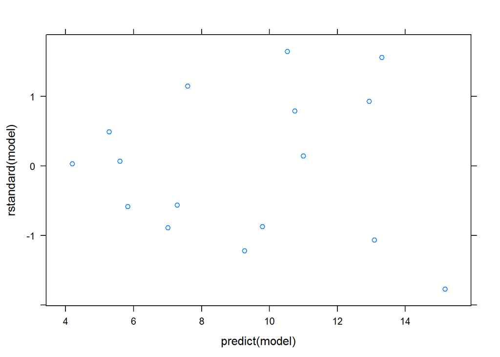

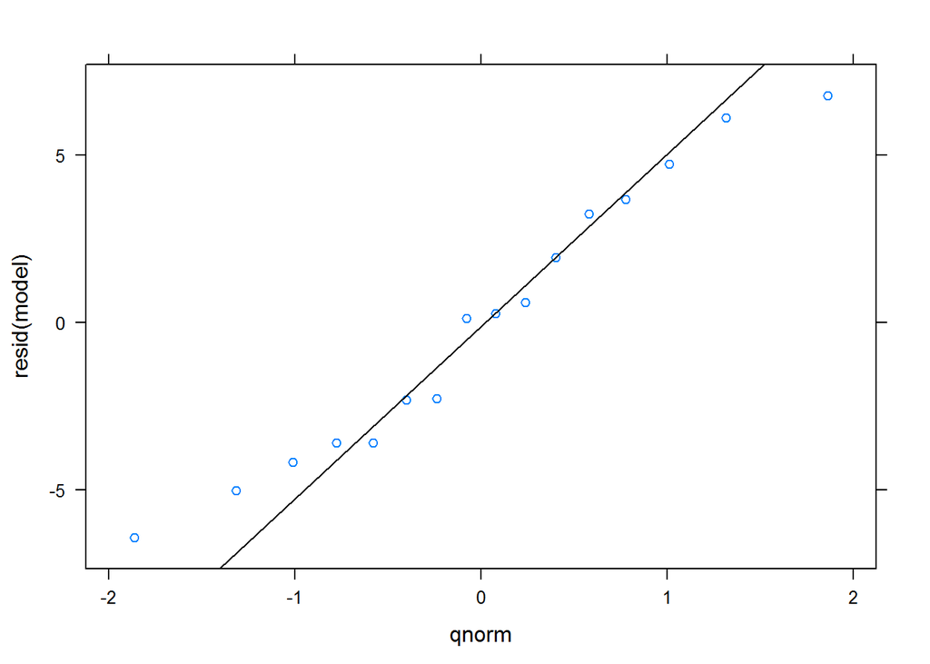

```r
> residual.analysis(Regression.Model.PB)
```

The equation is PBF = 0.025PBV -0.028; $r^2$ = 0.3937. The F and p value are 9.091 and 0.0093 respectively at the $\alpha = 0.05$ level of significance which means that there is sufficient evidence to reject the null hypothesis in this case.

13.10.4 (5pts): Show a scatterplot as well as doing the test. Refer to Exercise 13.10.3. Nozawa et al. also calculated the Japanese Orthopaedic Association score for measuring back pain (JOA). The results for the 20 subjects along with the duration of follow-up are shown in the following table. The higher the number, the lesser the degree of pain. Can we conclude from these data that in general there is a relationship between length of follow-up and JOA score at the time of the operation? Let $\alpha$ = 0.05.

```r
> backpain = read_csv("EXR_C13_S10_04.csv")
```

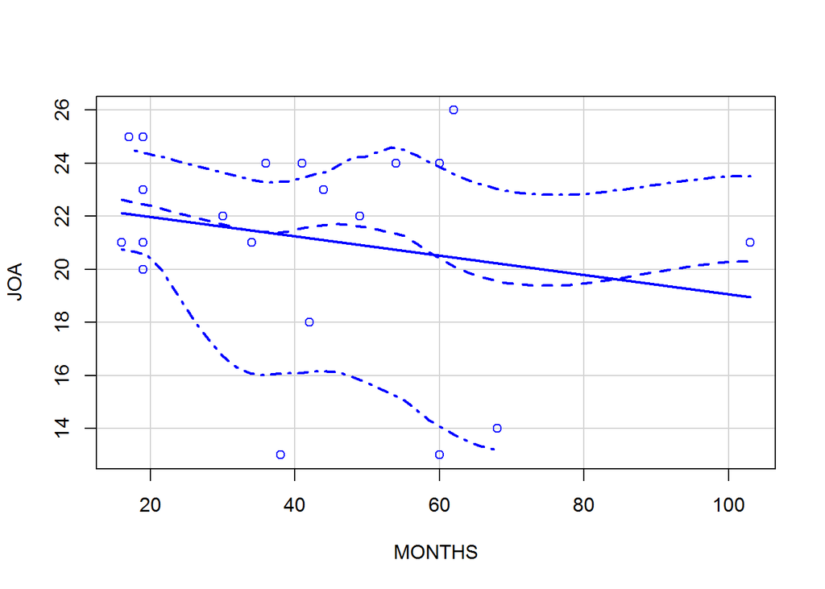

```r
> scatterplot(JOA~MONTHS, data=backpain, boxplots=F )
```

```r
> cat('JOA score w/ spearman non-parametric:'); cor(JOA~MONTHS,data=backpain,method='spearman')
```

```
JOA score w/ spearman non-parametric:
```

```
[1] -0.1047632
```

3 predictors: 10.3.2, 10.4.2, 10.5.2 all use 10.3.2 data (10pts) Family caregiving of older adults is more common in Korea than in the United States. Son et al. studied 100 caregivers of older adults with dementia in Seoul, South Korea. The dependent variable was caregiver burden as measured by the Korean Burden Inventory (KBI). Scores ranged from 28 to 140, with higher scores indicating higher burden. Explanatory variables were indexes that measured the following:

ADL: Total activites of daily living (low scores indicate that the elderly perform activities independently).

MEM: Memory and behavioral problems (higher scores indicate more problems).

COG: Cognitive impairment (lower scores indicate a greater degree of cognitive impairment).

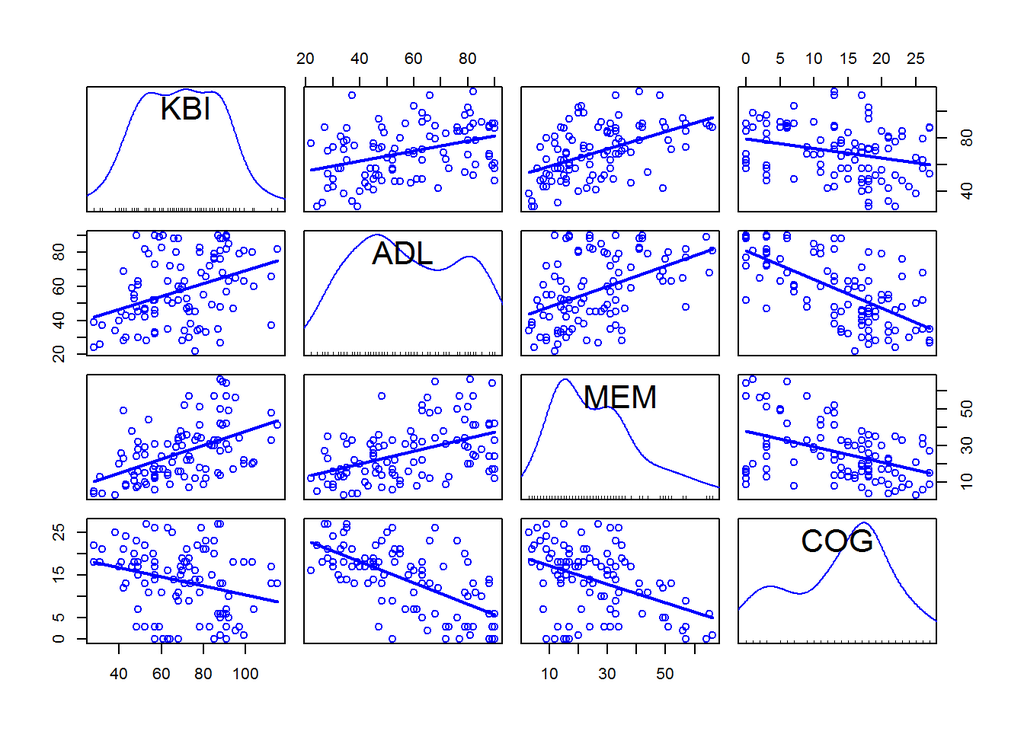

```r
> care <-
+   read.csv("EXR_C10_S03_02.csv")
>
> scatterplotMatrix(~KBI+ADL+MEM+COG, smooth=FALSE,
+   diagonal = 'density', data=care)
```

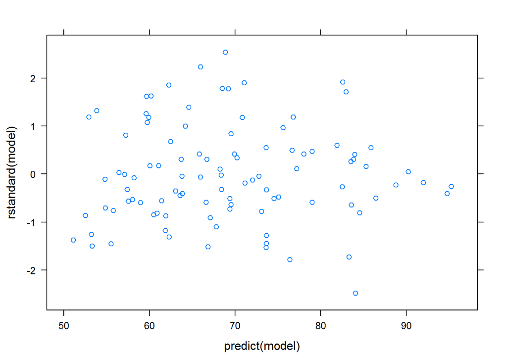

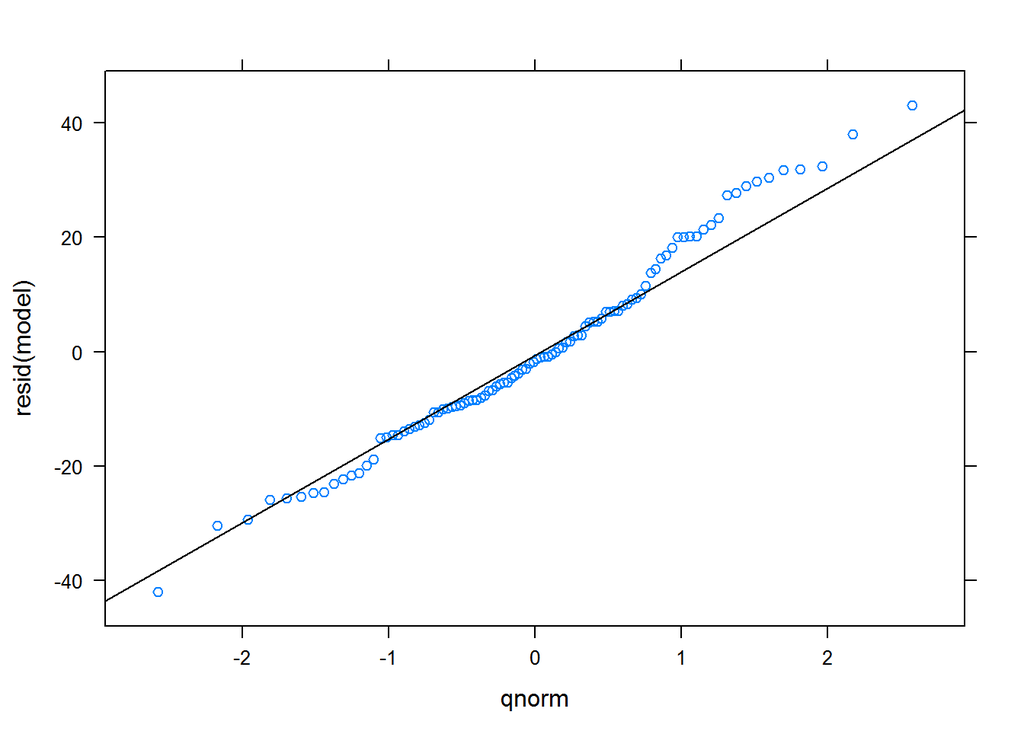

```r
> RegModel.care <- lm(KBI~ADL+MEM+COG, data=care)
> residual.analysis(RegModel.care)
```

```r
> summary(RegModel.care)
```

```
Call:
lm(formula = KBI ~ ADL + MEM + COG, data = care)

Residuals:
    Min      1Q  Median      3Q     Max
-42.037 -10.535  -1.503   9.213  43.151

Coefficients:
            Estimate Std. Error t value Pr(>|t|)
(Intercept)  40.4908    10.1030   4.008 0.000121 ***
ADL           0.2162     0.1168   1.851 0.067273 .
MEM           0.5547     0.1300   4.267 4.65e-05 ***
COG           0.1210     0.3003   0.403 0.687978
---
Signif. codes:  0 '***' 0.001 '**' 0.01 '*' 0.05 '.' 0.1 ' ' 1

Residual standard error: 17.26 on 96 degrees of freedom
Multiple R-squared:  0.282, Adjusted R-squared:  0.2596
F-statistic: 12.57 on 3 and 96 DF,  p-value: 5.315e-07
```

```r
> cor(care[,c("KBI","ADL","MEM","COG")], use="complete")
```

```
           KBI        ADL        MEM        COG
KBI  1.0000000  0.3798958  0.5019905 -0.2757502
ADL  0.3798958  1.0000000  0.4557426 -0.6470085
MEM  0.5019905  0.4557426  1.0000000 -0.4297546
COG -0.2757502 -0.6470085 -0.4297546  1.0000000
```

```r
> partial.cor(care[,c("KBI","ADL","MEM","COG")], use="complete")
```

```
 Partial correlations:
        KBI      ADL      MEM      COG
KBI 0.00000  0.18561  0.39928  0.04108
ADL 0.18561  0.00000  0.15840 -0.55873
MEM 0.39928  0.15840  0.00000 -0.19846
COG 0.04108 -0.55873 -0.19846  0.00000

 Number of observations: 100
```

```r
> newdata = data.frame(ADL=c(95), MEM=c(35), COG=c(0))
> # This creates a point at which we're interested in the intervals. Note that a
> # list of points could be defined with newdata = data.frame(X=c(1,2,3))
> predict(RegModel.care,newdata,interval = 'confidence')
```

```
       fit      lwr      upr
1 80.44049 72.60566 88.27533
```

```r
> predict(RegModel.care,newdata,interval='predict')
```

```
       fit      lwr      upr
1 80.44049 45.29739 115.5836
```

R insisted that I have a value for all three independent variables to construct intervals. Only two are given in the problem statement. I expect that one of the three ‘COG’ is not significant and is to be excluded. I’m not sure how to do this in R.

A. Calculate the coefficient of multiple determination B. Perform an analysis of variance C. Test the significance of each $\beta_i$(i>0). Let $\alpha$ = 0.05 for all tests of significance and determine the p value for all tests

D. Construct a 95 percent confidence interval for each significant sample slope.

E. Compute the y value and construct a 95 percent confidence and 95 percent prediction interval for $x_1j$=95 and $x_2j$=35.

6 predictors: 10.3.6, 10.4.6, 10.5.6 All use 10.3.6 data (10pts) The following data were collected on a simple random sample of 20 patients with hypertension. The variables are Y = mean arterial blood pressure (mmHg) $X_1$=age(years) $X_2$=weight(kg) $X_3$=body surface area($m^2$) $X_4$=duration of hypertension(years) $X_5$=basal bulse(bpm) $X_6$=measure of stress A. Calcultate the coefficient of multiple determination B. Perform an analysis of variance C. Test the significance of each $\beta_i$(i>0). Let $\alpha$ = 0.05 for all tests of significance and determine the p value for all tests D. Construct a 95 percent confidence interval for each significant sample slope. E. Compute the y value and construct a 95 percent confidence and 95 percent prediction interval for $x_1j$=50 $x_2j$=95 $x_3j$=2.00 $x_4j$=6.00 $x_5j$=75 $x_6j$=70

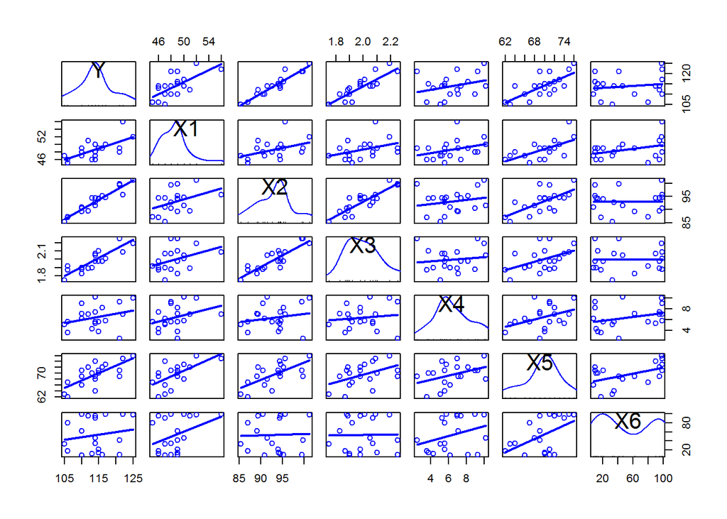

```r
> hypertension <-
+   read.csv("EXR_C10_S03_06.csv")
>
> scatterplotMatrix(~Y+X1+X2+X3+X4+X5+X6, smooth=FALSE,
+   diagonal = 'density', data=hypertension)
```

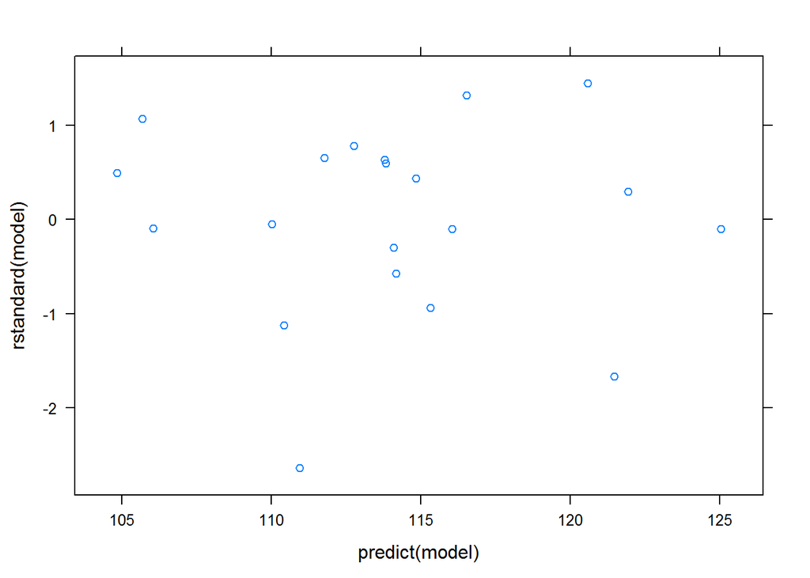

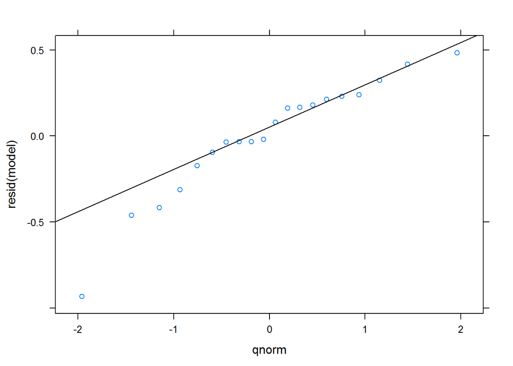

```r
> RegModel.hypertension <- lm(Y~X1+X2+X3+X4+X5+X6, data=hypertension)
> residual.analysis(RegModel.hypertension)
```

```r
> summary(RegModel.hypertension)
```

```
Call:
lm(formula = Y ~ X1 + X2 + X3 + X4 + X5 + X6, data = hypertension)

Residuals:
     Min       1Q   Median       3Q      Max
-0.93213 -0.11314  0.03064  0.21834  0.48454

Coefficients:
              Estimate Std. Error t value Pr(>|t|)
(Intercept) -12.870476   2.556650  -5.034 0.000229 ***
X1            0.703259   0.049606  14.177 2.76e-09 ***
X2            0.969920   0.063108  15.369 1.02e-09 ***
X3            3.776491   1.580151   2.390 0.032694 *
X4            0.068383   0.048441   1.412 0.181534
X5           -0.084485   0.051609  -1.637 0.125594
X6            0.005572   0.003412   1.633 0.126491
---
Signif. codes:  0 '***' 0.001 '**' 0.01 '*' 0.05 '.' 0.1 ' ' 1

Residual standard error: 0.4072 on 13 degrees of freedom
Multiple R-squared:  0.9962,    Adjusted R-squared:  0.9944
F-statistic: 560.6 on 6 and 13 DF,  p-value: 6.395e-15
```

```r
> cor(hypertension[,c("X1","X2","X3","X4","X5","X6")], use="complete")
```

```
          X1         X2         X3        X4        X5         X6
X1 1.0000000 0.40734926 0.37845460 0.3437921 0.6187643 0.36822369
X2 0.4073493 1.00000000 0.87530481 0.2006496 0.6593399 0.03435475
X3 0.3784546 0.87530481 1.00000000 0.1305400 0.4648188 0.01844634
X4 0.3437921 0.20064959 0.13054001 1.0000000 0.4015144 0.31163982
X5 0.6187643 0.65933987 0.46481881 0.4015144 1.0000000 0.50631008
X6 0.3682237 0.03435475 0.01844634 0.3116398 0.5063101 1.00000000
```

```r
> partial.cor(hypertension[,c("X1","X2","X3","X4","X5","X6")], use="complete")
```

```
 Partial correlations:
         X1       X2       X3       X4       X5       X6
X1  0.00000 -0.18401  0.24192  0.12969  0.40146  0.01842
X2 -0.18401  0.00000  0.85554  0.01133  0.68196 -0.42531
X3  0.24192  0.85554  0.00000 -0.03695 -0.42937  0.22779
X4  0.12969  0.01133 -0.03695  0.00000  0.13724  0.10166
X5  0.40146  0.68196 -0.42937  0.13724  0.00000  0.56856
X6  0.01842 -0.42531  0.22779  0.10166  0.56856  0.00000

 Number of observations: 20
```

```r
> newdata = data.frame(X1=c(50),X2=c(95),X3=c(2.00),X4=c(6.00),X5=c(75),X6=c(70))
> # This creates a point at which we're interested in the intervals. Note that a
> # list of points could be defined with newdata = data.frame(X=c(1,2,3))
> predict(RegModel.hypertension,newdata,interval = 'confidence')
```

```
       fit      lwr      upr
1 116.4518 116.0167 116.8869
```

```r
> predict(RegModel.hypertension,newdata,interval='predict')
```

```
       fit      lwr      upr
1 116.4518 115.4703 117.4333
```

I think that his problem also suffers from the fact that I’m unsure how to eliminate factors that are not significant. I think that would substantially change my results.